# R’s 3 Graphics Systems

There are three major graphics systems in R: 1 Base graphics 2 Lattice graphics 3 ggplot2

Additionally, there is a significant amount of development work going on to allow R users to produce interactive Javascript based plots. In this module we ill give an example of plotting histograms in all three systems.

### Base Graphics Histograms

In this first block of code we load the data set which is organized as a data frame and break out the data for each category into separate vectors. We do this because the base R hist function expects a vector as input.

```r
library(car)
data(Duncan)
dim(Duncan)
```

```
[1] 45  4
```

```r
head(Duncan)
```

|  | type | income | education | prestige |
| --- | --- | --- | --- | --- |
| accountant | prof | 62 | 86 | 82 |
| pilot | prof | 72 | 76 | 83 |
| architect | prof | 75 | 92 | 90 |
| author | prof | 55 | 90 | 76 |
| chemist | prof | 64 | 86 | 90 |
| minister | prof | 21 | 84 | 87 |

```r
# Select data using basic subsetting
inc_prof <- Duncan[Duncan$type=="prof","income"]
inc_bc <- Duncan[Duncan$type=="bc","income"]
inc_wc <- Duncan[Duncan$type=="wc","income"]
```

In this next block of code we first use the `par` command to set up a “panel” on the graphics output device to contain three side-by-side plots, then we plot each histogram one by one.

```r
par(mfrow=c(1,3))  # set option to put 3 plots in one pane
hist(inc_bc, prob = TRUE, col = "pink", main = ("Income BC"), xlab=("Dollars"))
             lines(density(inc_bc))
```

```r
hist(inc_prof, prob = TRUE, col = "yellow", main = ("Income Prof"), xlab=("Dollars"))
             lines(density(inc_prof))
```

```r
hist(inc_wc, prob = TRUE, col = "light blue", main = ("Income WC"), xlab=("Dollars"))
lines(density(inc_wc))
```

[figure not shown]

```r
par(mfrow=c(1,1))
```

### Lattice (trellis) Graphics

Lattice graphics are the second major plotting system in R. Plots built with lattice have a very distinctive look, but the real value is the ease of making trellis plots - graphs that display a variable conditioned on an other variable. Some useful websites are: http://www.statmethods.net/advgraphs/trellis.html http://user2007.org/program/presentations/sarkar.pdf

You can see that lattice has a `panel` parameter that can be set in the histogram. Also notice tht the `histogram()` function expects a data frame as input.

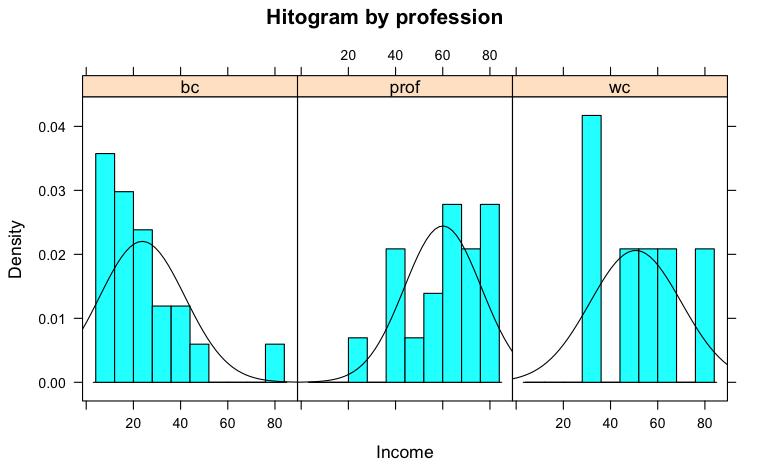

```r
library(lattice)
histogram( ~ income | type,
           data = Duncan,
           nint=10,
           xlab = "Income",
           main= "Hitogram by profession",
           type = "density",
           panel = function(x, ...) {
             panel.histogram(x, ...)
             panel.mathdensity(dmath = dnorm, col = "black",
                               args = list(mean=mean(x),sd=sd(x)))
           } )
```

### ggplot2 Graphics

ggplot is the third major plotting system for R. It is based on Leland Wilkinson’s grammar of graphics. Plots are built in layers. Some useful websites are: http://www.cs.uic.edu/~wilkinson/TheGrammarOfGraphics/GOG.html https://ggplot2.tidyverse.org/ http://www.cookbook-r.com/Graphs/ https://www.rstudio.com/wp-content/uploads/2015/03/ggplot2-cheatsheet.pdf

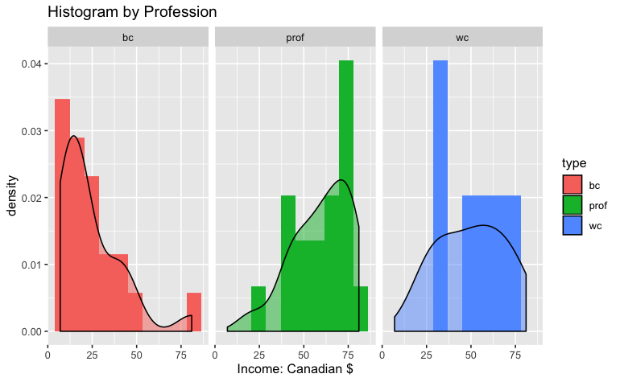

```r
library(ggplot2)
p1 <- ggplot(Duncan,aes(income,..density.., fill=type))
p1 + geom_histogram(bins=10) +
     facet_grid(. ~ type) +
     geom_density(alpha = .5) +
     xlab("Income: Canadian $") +
     ggtitle("Histogram by Profession")
```